# Method 1. Lagged effects in temporally explicit causal models

Author

Sam Walmsley, Suchinta Arif, Hal Whitehead

This example shows how reciprocal effects between traits can be extracted from longitudinal datasets. Here we fit a model similar to a cross-lagged panel model, where two traits are assumed to influence themselves and one another across successive timesteps.

We begin by loading several key packages:

```r
library(data.table)
library(ggplot2)
library(dplyr)
library(bayesplot)
library(brms)
library(posterior)
```

## Part 1 - Simple model

First, we will initialize variables for the simulation. These can be modified to explore how different effect and sample sizes impact the estimates that the model recovers. Note however that simulated positive feedbacks can result in massive values which can be tricky to model.

```r
# Initialize variables
n_time_steps <- 50

# auto effects (dampening)
a_to_a <- 0.25
b_to_b <- 0.25

# cross effects
a_to_b <- 1
b_to_a <- -1

# Create an empty data frame to store the results
df <- data.frame(
  time = integer(),
  a = numeric(),
  b = numeric())
```

Next, we loop over the time steps allowing the variables A and B to evolve as a function of both auto-regressive and bi-directional effects. Finally, we create columns containing lagged values of each variable to facilitate modelling the effects of previous variable values on current ones.

```r
# Initialize starting values
a <- numeric(n_time_steps)
b <- numeric(n_time_steps)
a[1] <- 1
b[1] <- 1

# Loop over time steps
for (t in 2:n_time_steps) {

  # A changes as a function of previous values of A (auto) and B (cross) plus random variation
  a[t] <- a_to_a * a[t-1] + b_to_a * b[t-1] + rnorm(1, mean = 0, sd = 0.25)

  # A changes as a function of previous values of A (auto) and B (cross) plus random variation
  b[t] <- b_to_b * b[t-1] + a_to_b * a[t-1] + rnorm(1, mean = 0, sd = 0.25)

}

# Combine the results into a dataframe
df <- data.frame(
  time = 1:n_time_steps,
  a = a,
  b = b)

# Convert from wide to long format for plotting with ggplot
df_long <- df %>%
  tidyr::pivot_longer(c(a, b), names_to = "trait", values_to = "value")

df <-
  df %>%
  mutate(a_1 = lag(a),
         b_1 = lag(b))
```

Now we are ready to fit the model. First we specify two formulas with A and B as outcomes, respectively. Each variable is expressed as a function of itself at a previous timestep, as well as the opposite variable at a previous timestep.

```r
f1 <- bf(b ~ 0 + Intercept + b_1 + a_1)
f2 <- bf(a ~ 0 + Intercept + a_1 + b_1)

m <-
  brm(data = df,
      family = 'Gaussian',
      f1 + f2 + set_rescor(FALSE),
      prior = c(prior(normal(0, 1), class = b, resp = b, coef = Intercept),
                prior(normal(0, 1), class = b, resp = a, coef = Intercept),
                prior(normal(0, 1), class = b, resp = b),
                prior(normal(0, 1), class = b, resp = a),
                prior(exponential(1), class = sigma, resp = b),
                prior(exponential(1), class = sigma, resp = a)),
      iter = 4000, warmup = 2000, chains = 4, cores = 4)
```

Next, we can examine the fitted model to see if the simulated (“true”) cross effects between A and B have been recovered.

```r
summary(m)
```

```
 Family: MV(gaussian, gaussian)
  Links: mu = identity; sigma = identity
         mu = identity; sigma = identity
Formula: b ~ 0 + Intercept + b_1 + a_1
         a ~ 0 + Intercept + a_1 + b_1
   Data: df (Number of observations: 49)
  Draws: 4 chains, each with iter = 4000; warmup = 2000; thin = 1;
         total post-warmup draws = 8000

Population-Level Effects:
            Estimate Est.Error l-95% CI u-95% CI Rhat Bulk_ESS Tail_ESS
b_Intercept     0.00      0.04    -0.08     0.08 1.00    13206     5705
b_b_1           0.24      0.02     0.21     0.28 1.00    14537     5958
b_a_1           0.97      0.02     0.93     1.01 1.00    13643     5588
a_Intercept    -0.04      0.03    -0.10     0.02 1.00    14531     5866
a_a_1           0.26      0.02     0.23     0.29 1.00    13180     5826
a_b_1          -0.98      0.02    -1.01    -0.95 1.00    13882     6034

Family Specific Parameters:
        Estimate Est.Error l-95% CI u-95% CI Rhat Bulk_ESS Tail_ESS
sigma_b     0.27      0.03     0.22     0.34 1.00    11754     6022
sigma_a     0.22      0.02     0.18     0.27 1.00    11342     5573

Draws were sampled using sampling(NUTS). For each parameter, Bulk_ESS
and Tail_ESS are effective sample size measures, and Rhat is the potential
scale reduction factor on split chains (at convergence, Rhat = 1).
```

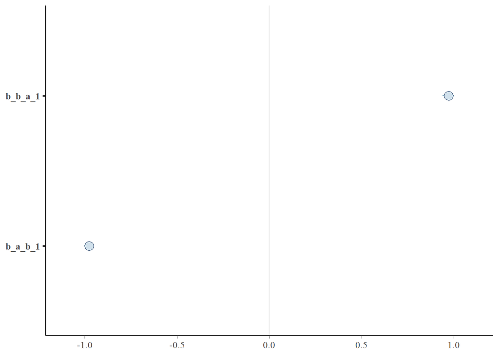

```r
mcmc_intervals(m, pars=c('b_b_a_1','b_a_b_1'))
```

Yes, the model has accurately recovered the causal, bidirectional effects. Note that “b_b_a_1” refers to the effect of A on B, while “b_a_b_1” refers to the effect of B on A, which were simulated as 1 and -1 respectively.

## Part 2 - Incorporating confounds

### Example 2.1. Hallucinated cross-lagged effects

For this example, we will simulate a situation in which A and B have no effects on one another. However, common influence from C, if ignored, may result in spurious estimates of bidirectional effects.

First, we will initialize variables for the simulation. These can be modified to explore how different effect and sample sizes impact the estimates that the model recovers. Note that we have included new effects for the common-cause confound, “C”.

```r
# Initialize variables
n_time_steps <- 50

# auto effects (dampening)
a_to_a <- 0.25
b_to_b <- 0.25
c_to_c <- 1

# cross effects
a_to_b <- 0.0
b_to_a <- 0.0

# add in confound
c_to_a <- 1
c_to_b <- 1

# Create an empty data frame to store the results
df <- data.frame(
  time = integer(),
  a = numeric(),
  b = numeric(),
  c = numeric())
```

As before, we simulate the temporal process by which A, B, and C change in response to one another over each time step. We also need to create lagged versions of each variable for modelling.

```r
# Initialize starting values
a <- numeric(n_time_steps)
b <- numeric(n_time_steps)
c <- numeric(n_time_steps)

a[1] <- 1
b[1] <- 1
c[1] <- 1

# Loop over time steps
for (t in 2:n_time_steps) {

  # A changes as a function of previous values of A (auto) and B (cross) plus random variation
  a[t] <- (a_to_a * a[t-1]) + (b_to_a * b[t-1]) + (c_to_a * c[t-1]) + rnorm(1, mean = 0, sd = 0.25)

  # A changes as a function of previous values of A (auto) and B (cross) plus random variation
  b[t] <- (b_to_b * b[t-1]) + (a_to_b * a[t-1]) + (c_to_b * c[t-1]) + rnorm(1, mean = 0, sd = 0.25)

  # C changes as a function of previous values of C (auto)
  c[t] <- (c_to_c * c[t-1]) + rnorm(1, mean = 0, sd = 0.25)

}

# Combine the results into a dataframe
df <- data.frame(
  time = 1:n_time_steps,
  a = a,
  b = b,
  c = c)


# Convert from wide to long format for plotting with ggplot
df_long <- df %>%
  tidyr::pivot_longer(c(a, b), names_to = "trait", values_to = "value")


df <-
  df %>%
  mutate(a_1 = lag(a),
         b_1 = lag(b),
         c_1 = lag(c))
```

First, we attempt a simple model without conditioning on the simulated confound, C.

```r
f1 <- bf(b ~ 0 + Intercept + b_1 + a_1)
f2 <- bf(a ~ 0 + Intercept + a_1 + b_1)

m <-
  brm(data = df,
      family = 'Gaussian',
      f1 + f2 + set_rescor(FALSE),
      prior = c(prior(normal(0, 1), class = b, resp = b, coef = Intercept),
                prior(normal(0, 1), class = b, resp = a, coef = Intercept),
                prior(normal(0, 1), class = b, resp = b),
                prior(normal(0, 1), class = b, resp = a),
                prior(exponential(1), class = sigma, resp = b),
                prior(exponential(1), class = sigma, resp = a)),
      iter = 4000, warmup = 2000, chains = 4, cores = 4)
```

As we can see in the model summary, the model does not confidently identify a lack of bidirectional effects between A and B, despite plenty of data. In fact, it identifies spurious (non-causal) reciprocal effects between A and B.

```r
summary(m)
```

```
 Family: MV(gaussian, gaussian)
  Links: mu = identity; sigma = identity
         mu = identity; sigma = identity
Formula: b ~ 0 + Intercept + b_1 + a_1
         a ~ 0 + Intercept + a_1 + b_1
   Data: df (Number of observations: 49)
  Draws: 4 chains, each with iter = 4000; warmup = 2000; thin = 1;
         total post-warmup draws = 8000

Population-Level Effects:
            Estimate Est.Error l-95% CI u-95% CI Rhat Bulk_ESS Tail_ESS
b_Intercept     0.47      0.19     0.09     0.85 1.00     7161     5720
b_b_1           0.35      0.20    -0.03     0.75 1.00     3984     3716
b_a_1           0.56      0.19     0.18     0.92 1.00     4140     3832
a_Intercept     0.32      0.19    -0.05     0.70 1.00     7051     4882
a_a_1           0.69      0.18     0.34     1.05 1.00     4058     3686
a_b_1           0.25      0.19    -0.11     0.61 1.00     3900     3871

Family Specific Parameters:
        Estimate Est.Error l-95% CI u-95% CI Rhat Bulk_ESS Tail_ESS
sigma_b     0.47      0.05     0.38     0.58 1.00     6471     5227
sigma_a     0.46      0.05     0.38     0.57 1.00     6905     5267

Draws were sampled using sampling(NUTS). For each parameter, Bulk_ESS
and Tail_ESS are effective sample size measures, and Rhat is the potential
scale reduction factor on split chains (at convergence, Rhat = 1).
```

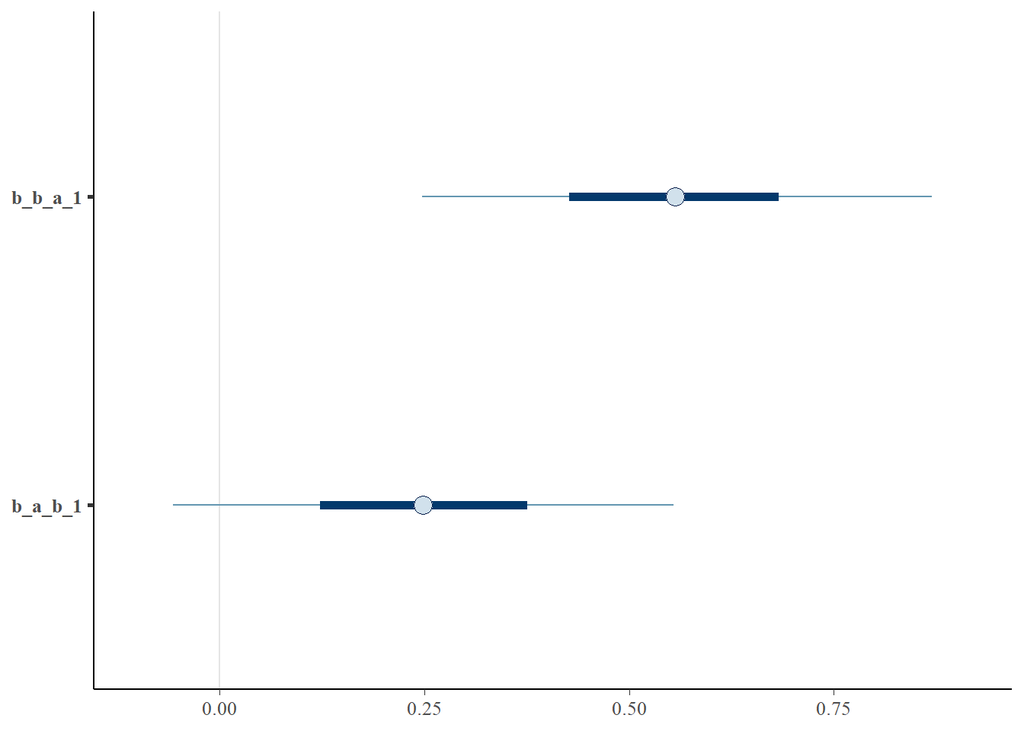

```r
mcmc_intervals(m, pars=c('b_b_a_1','b_a_b_1'))
```

```r
summary(m)
```

[output not shown]

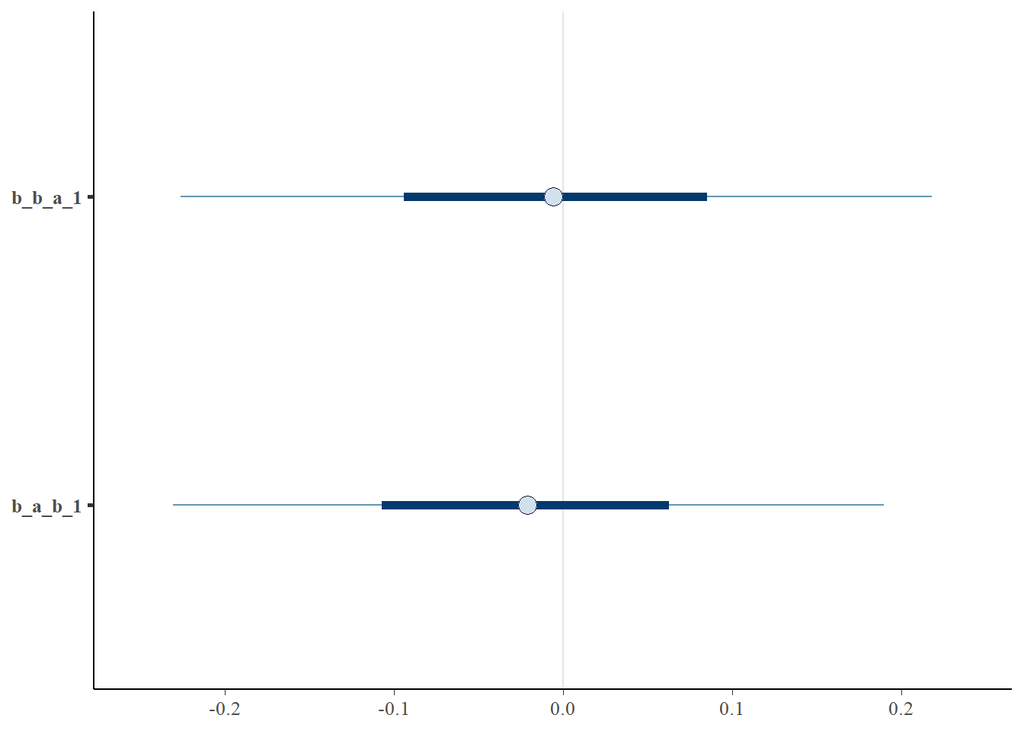

```r
mcmc_intervals(m, pars=c('b_b_a_1','b_a_b_1'))
```

As expected, the correctly adjusted model recovers the lack of causal effects between A and B.

### Example 2.2. Innacurate cross-lagged effects

In this example we will consider situations in which non-zero bidirectional effects are present, but the confound impacts our ability to estimate them accurately.

First, we will initialize variables for the simulation. These can be modified to explore how different effect and sample sizes impact the estimates that the model recovers. Here we simulate strong effects of the confound C, a weak positive effect of A on B, and a stronger negative effect of B on A.

```r
# Initialize variables
n_time_steps <- 50

# auto effects (dampening)
a_to_a <- 0.25
b_to_b <- 0.25
c_to_c <- 1

# cross effects
a_to_b <- 0.25
b_to_a <- -1

# add in confound
c_to_a <- 1
c_to_b <- 1

# Create an empty data frame to store the results
df <- data.frame(
  time = integer(),
  a = numeric(),
  b = numeric(),
  c = numeric())
```

```r
# Initialize starting values
a <- numeric(n_time_steps)
b <- numeric(n_time_steps)
c <- numeric(n_time_steps)

a[1] <- 1
b[1] <- 1
c[1] <- 1

# Loop over time steps
for (t in 2:n_time_steps) {

  # A changes as a function of previous values of A (auto) and B (cross) plus random variation
  a[t] <- (a_to_a * a[t-1]) + (b_to_a * b[t-1]) + (c_to_a * c[t-1]) + rnorm(1, mean = 0, sd = 0.1)

  # A changes as a function of previous values of A (auto) and B (cross) plus random variation
  b[t] <- (b_to_b * b[t-1]) + (a_to_b * a[t-1]) + (c_to_b * c[t-1]) + rnorm(1, mean = 0, sd = 0.1)

  # C changes as a function of previous values of C (auto)
  c[t] <- c_to_c*c[t-1] + rnorm(1, mean = 0, sd = 0.1)

}

# Combine the results into a dataframe
df <- data.frame(
  time = 1:n_time_steps,
  a = a,
  b = b,
  c = c)

# Convert from wide to long format for plotting with ggplot
df_long <- df %>%
  tidyr::pivot_longer(c(a, b), names_to = "trait", values_to = "value")

df <-
  df %>%
  mutate(a_1 = lag(a),
         b_1 = lag(b),
         c_1 = lag(c))
```

Here we fit a simple model with cross-lagged effects in which we do not explicitly control for the confound, C.

```r
f1 <- bf(b ~ 0 + Intercept + b_1 + a_1)
f2 <- bf(a ~ 0 + Intercept + a_1 + b_1)

m <-
  brm(data = df,
      family = 'Gaussian',
      f1 + f2 + set_rescor(FALSE),
      prior = c(prior(normal(0, 1), class = b, resp = b, coef = Intercept),
                prior(normal(0, 1), class = b, resp = a, coef = Intercept),
                prior(normal(0, 1), class = b, resp = b),
                prior(normal(0, 1), class = b, resp = a),
                prior(exponential(1), class = sigma, resp = b),
                prior(exponential(1), class = sigma, resp = a)),
      iter = 4000, warmup = 2000, chains = 4, cores = 4)

summary(m)
```

```
 Family: MV(gaussian, gaussian)
  Links: mu = identity; sigma = identity
         mu = identity; sigma = identity
Formula: b ~ 0 + Intercept + b_1 + a_1
         a ~ 0 + Intercept + a_1 + b_1
   Data: df (Number of observations: 49)
  Draws: 4 chains, each with iter = 4000; warmup = 2000; thin = 1;
         total post-warmup draws = 8000

Population-Level Effects:
            Estimate Est.Error l-95% CI u-95% CI Rhat Bulk_ESS Tail_ESS
b_Intercept     0.25      0.13    -0.00     0.50 1.00     4399     4867
b_b_1           0.93      0.07     0.79     1.07 1.00     3866     4578
b_a_1           0.23      0.09     0.04     0.41 1.00     5628     5669
a_Intercept     0.39      0.13     0.14     0.63 1.00     3926     4834
a_a_1           0.17      0.09    -0.01     0.34 1.00     5184     4983
a_b_1          -0.38      0.07    -0.52    -0.24 1.00     3608     4076

Family Specific Parameters:
        Estimate Est.Error l-95% CI u-95% CI Rhat Bulk_ESS Tail_ESS
sigma_b     0.17      0.02     0.14     0.21 1.00     6980     5231
sigma_a     0.16      0.02     0.13     0.20 1.00     6799     5740

Draws were sampled using sampling(NUTS). For each parameter, Bulk_ESS
and Tail_ESS are effective sample size measures, and Rhat is the potential
scale reduction factor on split chains (at convergence, Rhat = 1).
```

```r
summary(m)
```

```
 Family: MV(gaussian, gaussian)
  Links: mu = identity; sigma = identity
         mu = identity; sigma = identity
Formula: b ~ 0 + Intercept + b_1 + a_1
         a ~ 0 + Intercept + a_1 + b_1
   Data: df (Number of observations: 49)
  Draws: 4 chains, each with iter = 4000; warmup = 2000; thin = 1;
         total post-warmup draws = 8000

Population-Level Effects:
            Estimate Est.Error l-95% CI u-95% CI Rhat Bulk_ESS Tail_ESS
b_Intercept     0.25      0.13    -0.00     0.50 1.00     4399     4867
b_b_1           0.93      0.07     0.79     1.07 1.00     3866     4578
b_a_1           0.23      0.09     0.04     0.41 1.00     5628     5669
a_Intercept     0.39      0.13     0.14     0.63 1.00     3926     4834
a_a_1           0.17      0.09    -0.01     0.34 1.00     5184     4983
a_b_1          -0.38      0.07    -0.52    -0.24 1.00     3608     4076

Family Specific Parameters:
        Estimate Est.Error l-95% CI u-95% CI Rhat Bulk_ESS Tail_ESS
sigma_b     0.17      0.02     0.14     0.21 1.00     6980     5231
sigma_a     0.16      0.02     0.13     0.20 1.00     6799     5740

Draws were sampled using sampling(NUTS). For each parameter, Bulk_ESS
and Tail_ESS are effective sample size measures, and Rhat is the potential
scale reduction factor on split chains (at convergence, Rhat = 1).
```

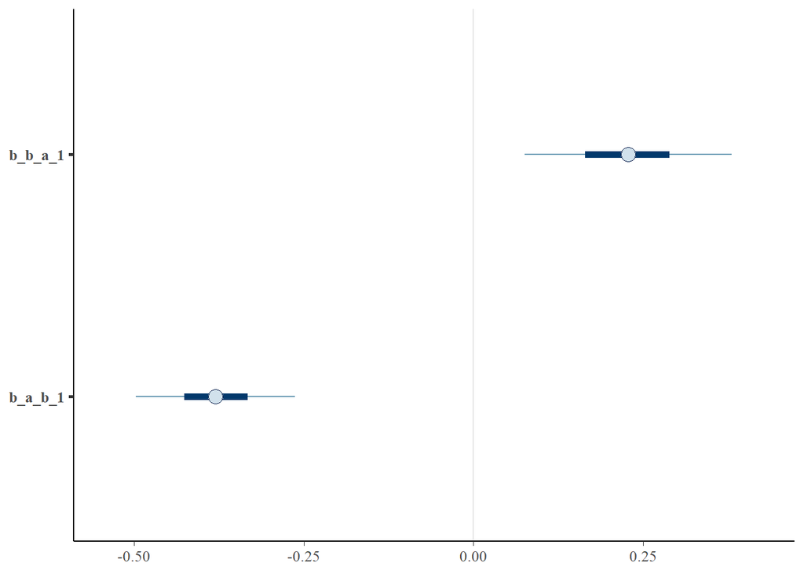

```r
mcmc_intervals(m, pars=c('b_b_a_1','b_a_b_1'))
```

Next, we fit the more causally appropriate model in which we condition on the known confound.

```r
f1 <- bf(b ~ 0 + Intercept + b_1 + a_1 + c_1)
f2 <- bf(a ~ 0 + Intercept + a_1 + b_1 + c_1)

m <-
  brm(data = df,
      family = 'Gaussian',
      f1 + f2 + set_rescor(FALSE),
      prior = c(prior(normal(0, 1), class = b, resp = b, coef = Intercept),
                prior(normal(0, 1), class = b, resp = a, coef = Intercept),
                prior(normal(0, 1), class = b, resp = b),
                prior(normal(0, 1), class = b, resp = a),
                prior(exponential(1), class = sigma, resp = b),
                prior(exponential(1), class = sigma, resp = a)),
      iter = 4000, warmup = 2000, chains = 4, cores = 4)

summary(m)
```

```
 Family: MV(gaussian, gaussian)
  Links: mu = identity; sigma = identity
         mu = identity; sigma = identity
Formula: b ~ 0 + Intercept + b_1 + a_1 + c_1
         a ~ 0 + Intercept + a_1 + b_1 + c_1
   Data: df (Number of observations: 49)
  Draws: 4 chains, each with iter = 4000; warmup = 2000; thin = 1;
         total post-warmup draws = 8000

Population-Level Effects:
            Estimate Est.Error l-95% CI u-95% CI Rhat Bulk_ESS Tail_ESS
b_Intercept    -0.08      0.10    -0.26     0.11 1.00     6107     5476
b_b_1           0.32      0.09     0.14     0.50 1.00     4575     4627
b_a_1           0.31      0.06     0.19     0.43 1.00     6561     5900
b_c_1           0.97      0.12     0.72     1.21 1.00     4281     4932
a_Intercept     0.08      0.09    -0.10     0.25 1.00     5406     5237
a_a_1           0.24      0.06     0.12     0.35 1.00     6200     5170
a_b_1          -0.97      0.08    -1.14    -0.80 1.00     4357     4009
a_c_1           0.93      0.11     0.71     1.16 1.00     4116     4511

Family Specific Parameters:
        Estimate Est.Error l-95% CI u-95% CI Rhat Bulk_ESS Tail_ESS
sigma_b     0.11      0.01     0.09     0.14 1.00     6411     5081
sigma_a     0.10      0.01     0.08     0.12 1.00     6430     5825

Draws were sampled using sampling(NUTS). For each parameter, Bulk_ESS
and Tail_ESS are effective sample size measures, and Rhat is the potential
scale reduction factor on split chains (at convergence, Rhat = 1).
```

```r
summary(m)
```

```
 Family: MV(gaussian, gaussian)
  Links: mu = identity; sigma = identity
         mu = identity; sigma = identity
Formula: b ~ 0 + Intercept + b_1 + a_1 + c_1
         a ~ 0 + Intercept + a_1 + b_1 + c_1
   Data: df (Number of observations: 49)
  Draws: 4 chains, each with iter = 4000; warmup = 2000; thin = 1;
         total post-warmup draws = 8000

Population-Level Effects:
            Estimate Est.Error l-95% CI u-95% CI Rhat Bulk_ESS Tail_ESS
b_Intercept    -0.08      0.10    -0.26     0.11 1.00     6107     5476
b_b_1           0.32      0.09     0.14     0.50 1.00     4575     4627
b_a_1           0.31      0.06     0.19     0.43 1.00     6561     5900
b_c_1           0.97      0.12     0.72     1.21 1.00     4281     4932
a_Intercept     0.08      0.09    -0.10     0.25 1.00     5406     5237
a_a_1           0.24      0.06     0.12     0.35 1.00     6200     5170
a_b_1          -0.97      0.08    -1.14    -0.80 1.00     4357     4009
a_c_1           0.93      0.11     0.71     1.16 1.00     4116     4511

Family Specific Parameters:
        Estimate Est.Error l-95% CI u-95% CI Rhat Bulk_ESS Tail_ESS
sigma_b     0.11      0.01     0.09     0.14 1.00     6411     5081
sigma_a     0.10      0.01     0.08     0.12 1.00     6430     5825

Draws were sampled using sampling(NUTS). For each parameter, Bulk_ESS
and Tail_ESS are effective sample size measures, and Rhat is the potential
scale reduction factor on split chains (at convergence, Rhat = 1).
```

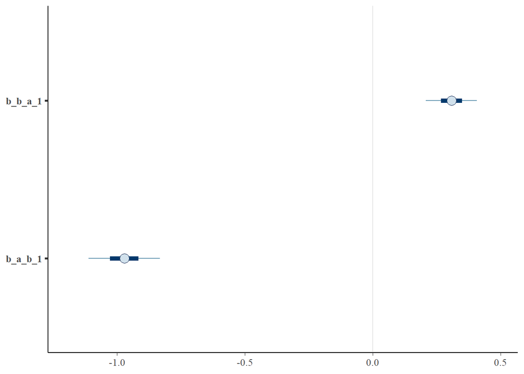

```r
mcmc_intervals(m, pars=c('b_b_a_1','b_a_b_1'))
```

Here, as expected, we recover more accurate estimates of the direct effects of A on B and of B on A.

## Sum-up

Here we have shown that temporally-explicit causal models with lag terms can accurately recover bidirectional effects. However, this model structure is not immune to the more general challenges of causal inference. Specifically, we show that it may be necessary to consider other causal pathologies (e.g.,confounding) in order to generate accurate causal inferences.